# STAT 240: ggplot2

# Overview

## Learning Outcomes

- These lectures will teach you how to:
  - Create basic graphs with ggplot2
  - Choose an appropriate graph based on the variable/question of interest
  - Visualize data among subgroups, whether on the same panel or across multiple
  - Manipulate specific elements of graphs with ggplot2

## Preliminaries

- For you to be able to run the code in this file, you need to put files in proper locations and might need to set the working directory.
- Let `COURSE` represent your course directory.
1. If it does not yet exist, create the folder `COURSE/lecture`.
2. Create the sub-folder `COURSE/lecture/unit2-ggplot2/`
3. If it does not yet exist, create the folder `COURSE/data/`
4. Download the file `week2-ggplot2.Rmd` into the `unit2-ggplot2` sub-folder.
5. Download the file `lake-mendota-winters-2023.csv` into the `COURSE/data/` folder.

## Introduction

- You will need the `lubridate` package for this file; run `install.packages("lubridate")` in your console.
- These notes introduce the Lake Mendota case study and the **ggplot2** package for making plots
- We use data from the Lake Mendota freeze/thaw data set to introduce several types of plots
- You can read the [chapter on Lake Mendota](https://bookdown.org/bret_larget/stat-240-case-studies/madison-lakes.html) from the Course Notes and Case Studies for background.

## Lake Mendota Dataset

- Scientists have been recording the dates when Lake Mendota first closes due to ice (at least half the surface is covered with ice) and opens (more than half the surface is liquid water) since the middle of the 1800s.
- This data set contains **one row for every winter season**, which starts in the late months of one year and ends in the early months of the next.
  - The first winter recorded is 1855-56, and the most recent winter recorded is 2022-23.
  - The variable `year1` is the first year of the given winter season.
  - The variable `duration` is the total number of days that Lake Mendota was closed in that winter.

### Read The Data

- The following R chunk has one line of code that will take the data in the .csv file and read it into a variable named `mendota`.

```r
## This assumes that:
### COURSE/data/ contains the data file
### COURSE/lectures/unit2-ggplot2/ is your working directory

mendota = read_csv("../../data/lake-mendota-winters-2023.csv")
```

### Exploring the Data

- `read_csv()` produces some colorful output; but just like there is scary-looking output when running `library(tidyverse)`, a lot of colorful output usually means the command worked.
- Double check the Preliminaries section if you get a single line that says ‘Warning: File “x” not found in current working directory “y”.’
- The output from `read_csv()` summarizes some important characteristics of the dataset, including:
  - specifies the number of rows and columns in the data set
  - the names and types of the columns (though this may get cut off if your dataset has many or long column names)
- `read_csv` tries to intelligently guess the type you want each variable to be.
  - We can also see the type of each column with `glimpse(mendota)`.

```r
glimpse(mendota)
```

```
## Rows: 168
## Columns: 7
## $ winter       <chr> "1855-56", "1856-57", "1857-58", "1858-59", "1859-60", "1…
## $ year1        <dbl> 1855, 1856, 1857, 1858, 1859, 1860, 1861, 1862, 1863, 186…
## $ intervals    <dbl> 1, 1, 1, 1, 1, 1, 1, 1, 1, 1, 1, 1, 1, 1, 1, 1, 1, 1, 1, …
## $ duration     <dbl> 118, 151, 121, 96, 110, 117, 132, 104, 125, 118, 125, 123…
## $ first_freeze <date> 1855-12-18, 1856-12-06, 1857-11-25, 1858-12-08, 1859-12-…
## $ last_thaw    <date> 1856-04-14, 1857-05-06, 1858-03-26, 1859-03-14, 1860-03-…
## $ decade       <dbl> 1850, 1850, 1850, 1850, 1850, 1860, 1860, 1860, 1860, 186…
```

- `<chr>` stands for “character”; the values in `winter` are character strings.
- `<dbl>` stands for “double”; this is the technical term for a numeric column. All columns except `winter`, `first_freeze`, and `last_thaw` are numeric.
- `<date>` represents dates which are specific to the level of day. Notice how `year1` is not read in as a date, because R does not know to distinguish between, say, 1855 the year and 1,855 the number. However, `first_freeze` and `last_thaw` specify a day within a year, so they are read in as dates.
  - For this data set, the guesses are all correct and no changes are required.
  - `read_csv`, with the underscore, is the tidyverse version of base R’s `read.csv` (with a dot). The tidyverse version makes more intelligent guesses on column types, and produces a `tibble` rather than a `data.frame`. For this reason, we always recommend and will write `read_csv` instead of `read.csv`.
- `View(mendota)` will bring up the whole dataframe in a different window. You can also, alternatively, click on the name “mendota” in your Environment tab. Take a second to review an individual row and make sure you specifically understand the relationship between `winter` and `year1`, and the relationship between `first-freeze`, `last_thaw`, and `duration`.

# An Introduction to ggplot2

> The **tidyverse** package **ggplot2** is based on a *grammar of graphics* (what the gg in ggplot2 stands for).
- Having a “grammar” of graphics is important because:
  - A wide variety of graph types can be implemented with extremely similar code
  - The user has a rich language to customize plots to a more rich degree than graphing software with pre-specified dropdown menu options
  - **Just like ordinary language, the creative combination of smaller building blocks can support a very wide range of expression.**

## Principles of ggplot2

- You provide ggplot2 a **dataframe/tibble**.
- You provide ggplot2 a **mapping**; namely, which variables in your dataframe should control which properties of the marks on your plot?
  - For example: I want the variable `year1` to dictate the `x` position (horizontal) of marks, and I want `duration` to dictate the `y` position (vertical) of marks
- With this established, you build the plot with **layers**.
  - First, you put the blank canvas down.
  - With the second layer, you will usually add the marks (our general term for the shapes on the graph; lines, points, bars, boxplots, etc.) on top of that canvas which correspond to the data, according to the established mapping.
  - Sometimes, we will add additional layers on top of this, and often we will customize features of previous layers.
- If you stop there, ggplot2 is perfectly capable of making reasonable visual decisions, including but not limited to:
  - The size, shape, color, and transparency of marks
  - The position, appearance, and labeling of axes
  - The general shape and appearance of the plot
- However, all of these things (and so many more - in fact, an overwhelming amount more) can be **customized**.

## Creating a Basic Plot with ggplot2

- This section will take you through the entire real process of creating a basic graph with ggplot2.

##### EXERCISE: Planning Out Your Graph

- We will begin to use ggplot2 by attempting to visually answer the question:

> How has the duration of time Lake Mendota closes due to ice each winter changed over the last 168 years?
- Before we start throwing code around at this ambitiously broad question, let’s form a plan of what we want our graph to look like.
- Toward this end, it can be useful to consider a much smaller subset of the full dataset; for example, the last six years.

```r
# The "opposite" of head()
mendota_small = tail(mendota)

mendota_small
```

```
## # A tibble: 6 × 7
##   winter  year1 intervals duration first_freeze last_thaw  decade
##   <chr>   <dbl>     <dbl>    <dbl> <date>       <date>      <dbl>
## 1 2017-18  2017         1       94 2017-12-27   2018-03-31   2010
## 2 2018-19  2018         2       86 2018-12-15   2019-03-31   2010
## 3 2019-20  2019         1       70 2020-01-12   2020-03-22   2010
## 4 2020-21  2020         1       76 2021-01-03   2021-03-20   2020
## 5 2021-22  2021         1       85 2022-01-07   2022-04-02   2020
## 6 2022-23  2022         1       98 2022-12-25   2023-04-02   2020
```

- How would you describe the pattern of `duration` over the last six years?
- How would you represent that pattern graphically? Draw an informal sketch or think about the shape of the graph.
- Did your sketch look something like this?

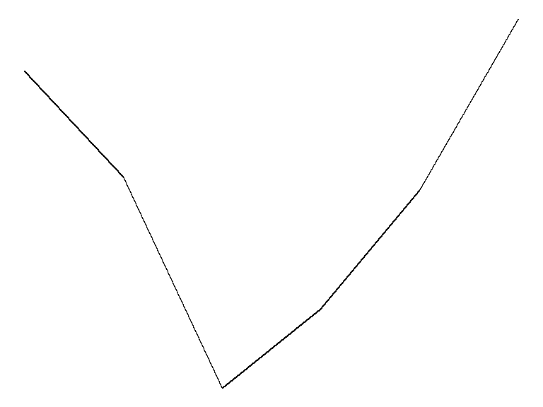

- This shape implies that `year1` is the x-variable, and `duration` is the y variable.

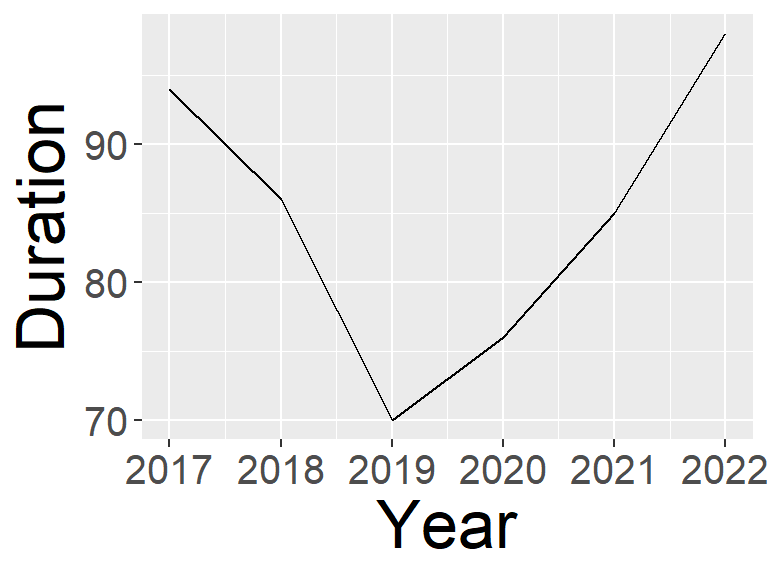

> The trend in the data is made extremely obvious and intuitive by this graph. This is what a good graph accomplishes, and its effectiveness depends on the choices you make.
- Notice how the following shape graph is less intuitive at showing the pattern. It’s still there, but requires more thought.

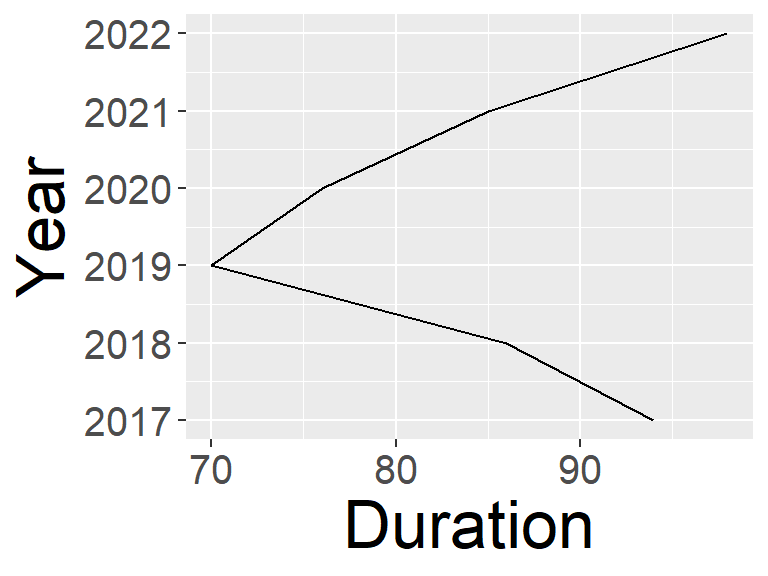

- Now let’s actually learn some code; we’ll create the first graph we decided on, but using the entire dataset!

### The First Layer

> Laying down the blank canvas is done with the function `ggplot()`.

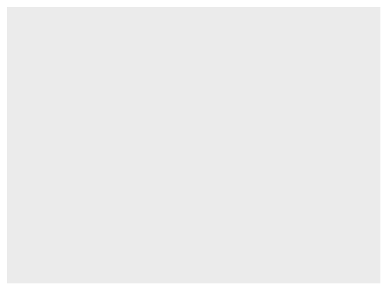

```r
ggplot()
```

- Arguments to `ggplot()` are where we will tell the plot what it needs to know: the data, and the mapping, as described in Principles.
  - From the help page for the `ggplot` function (recall: run `?ggplot` in your console to bring it up), the first two arguments are named `data` and `mapping`.
  - `data` is simply the dataframe you want to graph; we will eventually use the full dataset; `mendota` from the earlier chunk, but I also use `mendota_small` (the last six rows only) for smaller examples.
  - `mapping` is a little more complicated. Rather than an object, you are going to give it a *function* which tells the plot what properties correspond with what variables.
- The `aes()` function, standing for “aesthetic”, is what you need to pass in as the `mapping`.
  - Within `aes()`, you specify as many or as few pairs as you want, which connect graph properties to variables in your dataframe you entered as `data`. These pairs take the form `graphProperty = variableName`, with pairs separated by commas.
  - For our plot, we want `year1` to control the `x` position of the line, and `duration` to control the `y` position of the line.

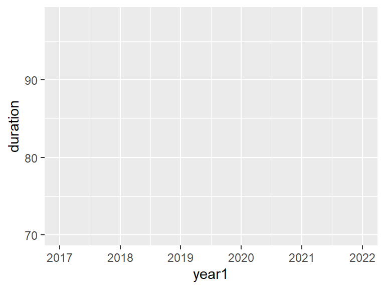

```r
ggplot(data = mendota_small, mapping = aes(x = year1, y = duration))
```

```r
# Sidenote: if you are a first-time coder, make sure you understand why this line ends with two parentheses! You can click your cursor to the RIGHT of a parentheses, and RStudio will highlight its match. Very useful when code gets more intense.

# The second of the two is the end of the much larger ggplot() function, which contains the data and mapping arguments.
# The first of the two is the end of the aes() function, which contains the x and y named arguments.
```

- The basic framework for the plot now exists upon the canvas, even though we haven’t put any marks on it yet; just like the instructions for the plot exist within the call to `ggplot`.
- Notice how ggplot2 has made intelligent decisions for how wide each axis should be, where the gridlines and labels are, et cetera.

### The Second Layer: Geom_ Functions

- Now, we need to add a layer *on top of* this canvas with a mark representing the data, which brings us to two important code concepts.

> Adding layers to a ggplot is accomplished by “adding” functions together with the `+` symbol. Each function creates a layer, and they will appear on the plot in the order you specify them in, back to front, like stacking plates.
- For example, in the chunk below, the `ggplot` call lays the canvas down, and then we will ADD the next layer on top, with some function to create the line.

```r
ggplot(data = mendota, mapping = aes(x = year1, y = duration) ) +
  some function to create the line...
```

- Notice the `+` is at the END of the first line, not the beginning of the second. Separating each function onto its own line is helpful visually, but not required.

> Adding a layer of marks to the canvas is done with the **geometry** functions, which take the form `geom_something`, where `something` is a descriptive name like `point` or `line`.
- There are dozens of `geom_` functions which indicate what type of mark you want to put on the plot, including but not limited to the list below. Many are intuitive, some are not.
  - `geom_line`
  - `geom_point`
  - `geom_text`
  - `geom_smooth`
  - `geom_boxplot`
  - `geom_histogram`
  - `geom_density`
  - `geom_bar`
  - `geom_col`
  - `geom_segment`
  - `geom_ribbon`
  - `geom_area`
  - `geom_violin`
- When other users create visualization packages, very often they will name their main visualization command `geom_something` and make it compatible with ggplot syntax.
  - For example, the [sf](https://ggplot2.tidyverse.org/reference/ggsf.html) package, standing for “spatial features”, includes `geom_sf` to plot geographic maps.
  - The ggimage package includes `geom_image` to plot images on a graph.
- In our quest to recreate the line graph from the exercise above, we will eventually use `geom_line`.
- However, before working up to that, we’ll start with (in my opinion) the easiest `geom` to understand: `geom_point`.
- `geom_point` requires TWO mappings: a numeric `x` and a numeric `y`. It places a single point (by default, a small black circle) for each row in your dataset.
  - `geom_point` does not require any arguments here, since we have already told the plot what dataframe we are using, and which variables represent `x` and `y`, within the first-line call to `ggplot`!
- It is instructive to look at the dataframe and connect each row with the point which represents it.

```r
# This code displays all rows (blank before comma) for the second and fourth column of the dataframe mendota_small.
mendota_small[ , c(2, 4)]
```

```
## # A tibble: 6 × 2
##   year1 duration
##   <dbl>    <dbl>
## 1  2017       94
## 2  2018       86
## 3  2019       70
## 4  2020       76
## 5  2021       85
## 6  2022       98
```

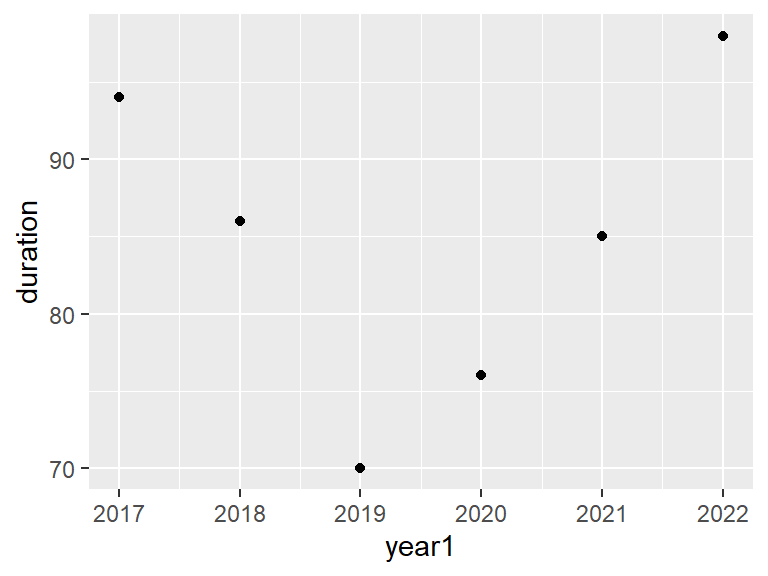

```r
ggplot(data = tail(mendota), mapping = aes(x = year1, y = duration) ) +
  geom_point()
```

- Now, let’s return to `geom_line`, which connects these points with a line (by default, a thin, black, solid line).

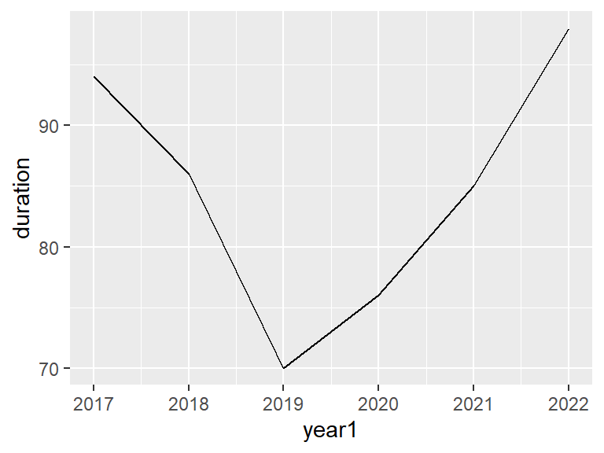

```r
ggplot(data = tail(mendota), mapping = aes(x = year1, y = duration) ) +
  geom_line()
```

- Finally, let’s take the training wheels off and use the full dataset!

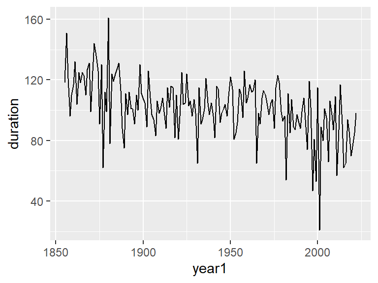

```r
# Replacing mendota_small with mendota
ggplot(data = mendota, mapping = aes(x = year1, y = duration) ) +
  geom_line()
```

- You just completed the fundamental visualization process! Congratulations!
- With two `geom`s at our disposal, we’re now going to introduce some more complex concepts in ggplot2, before getting to the “Gallery of Geoms”.